# REGRESION LOGISTICA - TP 2

# Interpretacion del modelo

## Tengan en cuenta que el codigo es orientador, cambienlo en funcion de lo que decidan hacer con el modelo.

## 1) cargamos los paquetes que vamos a usar durante el análisis.

```r
library(data.table)
library(tidyverse)
library(broom)
library(vcd)
library(sjPlot)
library(epiR)
library(gtsummary)
library(tableone)
library(ggpubr)
library(vcd)
library(vcdExtra)
library(CalibrationCurves)
library(pROC)
library(glmnet)
```

## 2) Traemos la base de datos desde la ubicacion donde vive

```r
setwd("~/DIEGO/PEC/LOGISTICA/Practicos")# recuerden cambiar la carpeta donde van a tener guardada la base de datos.
datos <- fread("framdata Ej 1.csv")
datos$smoke <- ifelse(datos$cig >0,1,0)
datos <- datos[,-c(7:10)]
```

## Objetivos del Modelo:

*Combinación de de variables que brinda la mejor respuesta a mi pregunta de investigación*

### Tipos de Modelo

- Predictivo: Modelo Parsimonioso

## Primer paso: Analisis Bivariable.

### Tabla 1

```r
datos[, c("sex", "smoke") := lapply(.SD, as.factor), .SDcols = c("sex", "smoke")]

catvars = c("sex", "smoke")
vars = c("age","sbp","dbp","chol","sex","smoke")

tabla_1 <- CreateTableOne(vars = vars, strata = "newchd", factorVars = catvars, data = datos)
kableone(tabla_1)
```

|  | 0 | 1 | p | test |
| --- | --- | --- | --- | --- |
| n | 1095 | 268 |  |  |
| age (mean (SD)) | 52.08 (4.75) | 53.58 (4.76) | <0.001 |  |
| sbp (mean (SD)) | 145.11 (26.28) | 158.57 (31.14) | <0.001 |  |
| dbp (mean (SD)) | 88.91 (13.53) | 94.58 (15.44) | <0.001 |  |
| chol (mean (SD)) | 232.99 (45.71) | 241.30 (48.42) | 0.008 |  |
| sex = 1 (%) | 479 (43.7) | 164 (61.2) | <0.001 |  |
| smoke = 1 (%) | 480 (43.9) | 134 (50.0) | 0.082 |  |

### Regresion Logística Simple

```r
datos %>%
  tbl_uvregression(
    method = glm,
    y = newchd,
    method.args = list(family = binomial),
    exponentiate = TRUE,
    pvalue_fun = ~style_pvalue(.x, digits = 2)
  ) %>%
  bold_p() %>%
  bold_labels()
```

| **Characteristic** | **N** | **OR** | **95% CI** | **p-value** |
| --- | --- | --- | --- | --- |
| age | 1,363 | 1.07 | 1.04, 1.10 | <0.001 |
| sbp | 1,363 | 1.02 | 1.01, 1.02 | <0.001 |
| dbp | 1,363 | 1.03 | 1.02, 1.04 | <0.001 |
| chol | 1,363 | 1.00 | 1.00, 1.01 | 0.009 |
| sex | 1,363 |  |  |  |
| 0 |  | — | — |  |
| 1 |  | 2.03 | 1.55, 2.67 | <0.001 |
| smoke | 1,362 |  |  |  |
| 0 |  | — | — |  |
| 1 |  | 1.28 | 0.98, 1.67 | 0.071 |

Abbreviations: CI = Confidence Interval, OR = Odds Ratio

```r
NA
NA
```

### Que hacemos con las numericas??

#### Decidir si colesterol (chol) queda como numerica o se categoriza de alguna forma…

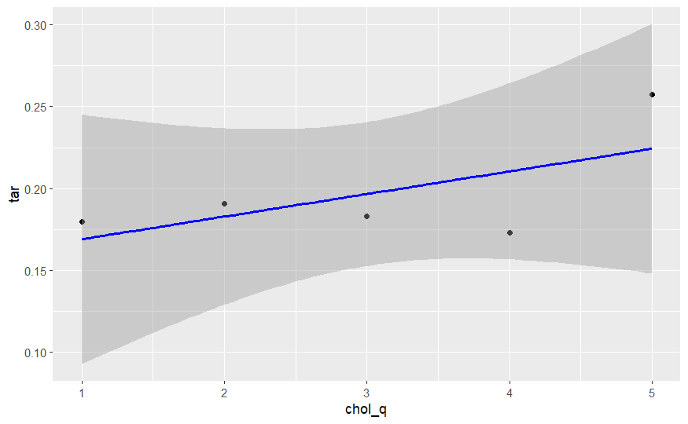

```r
datos<- datos %>% mutate(chol_q = ntile(chol, 5))


datos %>% dplyr::group_by(chol_q) %>% dplyr::summarise(tar=mean(newchd)) %>% ggplot(aes(x=chol_q, y=tar))+geom_point()+geom_smooth(method = "lm", col = "blue")
```

```r
NA
NA
```

#### Decidir si edad (age) queda como numerica o se categoriza de alguna forma…

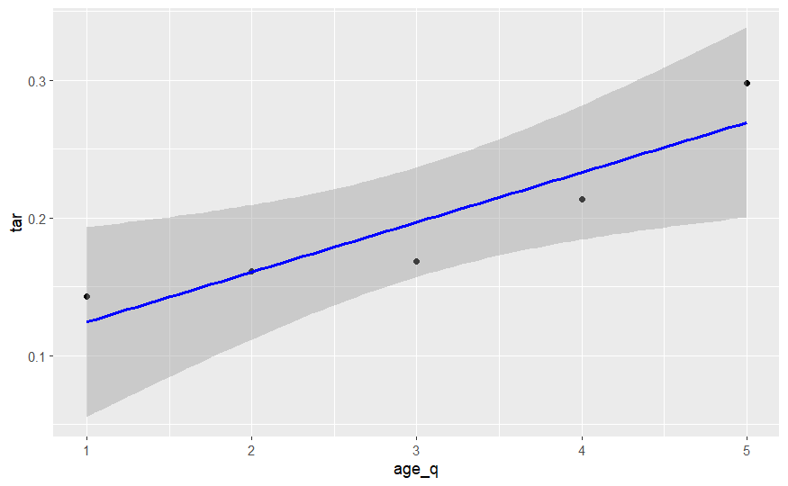

```r
datos<- datos %>% mutate(age_q = ntile(age, 5))


datos %>% dplyr::group_by(age_q) %>% dplyr::summarise(tar=mean(newchd)) %>% ggplot(aes(x=age_q, y=tar))+geom_point()+geom_smooth(method = "lm", col = "blue")
```

```r
NA
NA
```

#### Decidir si presion sistolica (sbp) queda como numerica o se categoriza de alguna forma…

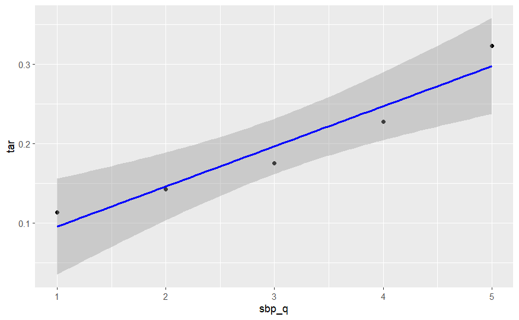

```r
datos<- datos %>% mutate(sbp_q = ntile(sbp, 5))


datos %>% dplyr::group_by(sbp_q) %>% dplyr::summarise(tar=mean(newchd)) %>% ggplot(aes(x=sbp_q, y=tar))+geom_point()+geom_smooth(method = "lm", col = "blue")
```

```r
NA
NA
```

#### Decidir si presion diastolica (dbp) queda como numerica o se categoriza de alguna forma…

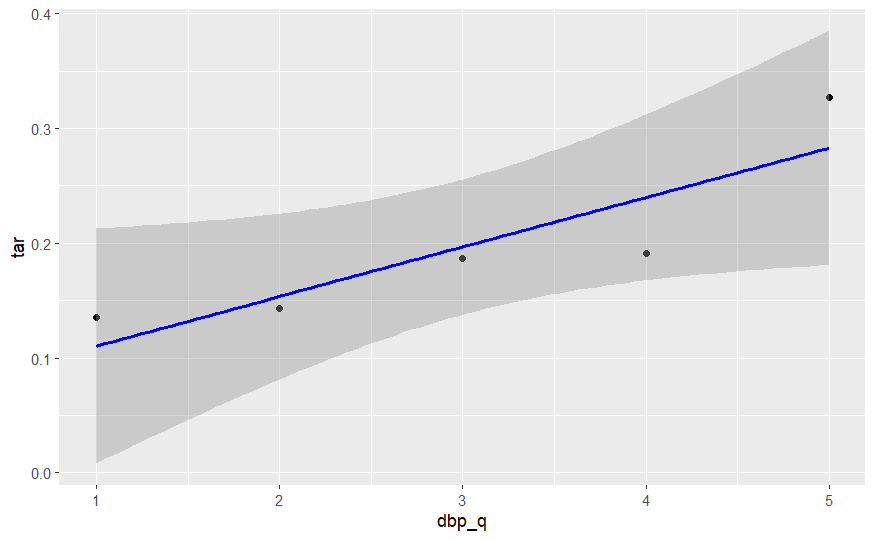

```r
datos<- datos %>% mutate(dbp_q = ntile(dbp, 5))


datos %>% dplyr::group_by(dbp_q) %>% dplyr::summarise(tar=mean(newchd)) %>% ggplot(aes(x=dbp_q, y=tar))+geom_point()+geom_smooth(method = "lm", col = "blue")
```

```r
NA
NA
```

#### sbp + dbp dejmos las dos ????

### Despues de todo lo eso, quieren volver a correr algun modelo bivariado?

En este caso, decidi dicotomizar chol y sbp en las variables dlp (5to quintil para arriba de colesterol y hta > 140 mmhg).

```r
datos$dlp <- as.factor(ifelse(datos$chol_q>4,1,0))
datos$hta <- as.factor(ifelse(datos$sbp > 140,1,0))

datos %>% dplyr::select(age, sex, newchd,smoke,dlp, hta) %>%
  tbl_uvregression(
    method = glm,
    y = newchd,
    method.args = list(family = binomial),
    exponentiate = TRUE,
    pvalue_fun = ~style_pvalue(.x, digits = 2)
  ) %>%
  bold_p() %>%
  bold_labels()
```

| **Characteristic** | **N** | **OR** | **95% CI** | **p-value** |
| --- | --- | --- | --- | --- |
| age | 1,363 | 1.07 | 1.04, 1.10 | <0.001 |
| sex | 1,363 |  |  |  |
| 0 |  | — | — |  |
| 1 |  | 2.03 | 1.55, 2.67 | <0.001 |
| smoke | 1,362 |  |  |  |
| 0 |  | — | — |  |
| 1 |  | 1.28 | 0.98, 1.67 | 0.071 |
| dlp | 1,363 |  |  |  |
| 0 |  | — | — |  |
| 1 |  | 1.56 | 1.14, 2.13 | 0.005 |
| hta | 1,363 |  |  |  |
| 0 |  | — | — |  |
| 1 |  | 2.26 | 1.71, 3.01 | <0.001 |

Abbreviations: CI = Confidence Interval, OR = Odds Ratio

```r
NA
NA
```

### Me aseguro que las variables categoricas tengan bien asignada su clase…. si es que cambie algo

```r
datos[, c("hta", "dlp") := lapply(.SD, as.factor), .SDcols = c("hta", "dlp")]
```